# Sweet spheres – Bunse et al. 2021

# This script: MT community analysis

8th May 2021

```r
rm(list = ls(all.names = TRUE))

library(readxl)
library(DESeq2)
library(magrittr)
library(summarytools)
library(tidyverse)
library(RColorBrewer)
library(ComplexHeatmap)
library(circlize)

set.seed(98765) #for reproducible code
```

# 1 Project

The data originate from the paper “Bunse, Koch, Breider, Simon and Wietz (2021) Sweet spheres: succession and CAZyme expression of marine bacterial communities colonizing a mix of alginate and pectin particles. Environmental Microbiology”. Please see description in the paper for details.

### 1.0.1 Data wrangling

- Normalised MT read abundances: TPM= transcripts per million
- dbcan - Coverage>=0.8
- DESeq2 analysis: Prefiltering low counts to minimum 10 counts per gene, significance defined as padj < 0.001 & LogFC ><2

### 1.0.2 Load datasets

List of datafiles used for these particular analyses:

- CP361_metadata_mod.xlsx # metadata and samplenames
- data.csv # transcriptome counts
- dbcan_coverage80.csv # dbcan annotation
- MetaG_KEGG_dbcan.xlsx # KEGG annotation

Note that in this script, “DNAsense_id” is called “sample”, “GeneID” = “locus_tag” and “ManuscriptID” = “experimental factor”.

```r
## Some general things:

#Colors for plots
col.treatment = c("CTR" = "#5f6161",
                  "ALG" = "#d9582e",
                  "PEC" = "#EBCC2A",
                  "AlgP" = "#d9582e",
                  "PecP" = "#EBCC2A",
                  "AlgF" = "#78B7C5",
                  "FL" = "#78B7C5",
                  "PecF" = "#3329c2",
                  "mALGPEC" = "#d9582e",
                  "fALGPEC" = "#78B7C5",
                  "T0" = "#7900f2",

                  "sign_NA_NA"="grey",
                  "NA_NA_FL"= "grey",
                  "NA_PA_NA"="grey",
                  "NA_NA_NA"= "grey",
                  "sign_PA_NA" ="red4",
                  "sign_NA_FL"= "#78B7C5",
                   "sign_NA_NA"="grey",
                  "NA_NA_AlgP"= "grey",
                  "NA_PecP_NA"="grey",
                  "sign_PecP_NA"="#EBCC2A",
                  "sign_NA_AlgP"= "#d9582e"
                  )


#filter option not-in
`%notin%` <- Negate(`%in%`)
```

metadata:

```r
# Load metadata and wrangle into usable format
metadata <- read_excel("data_used/CP361_metadata_mod.xlsx") %>%
  select(Samplename,Type,Experiment, Replicate, ManuscriptID) %>%
  mutate(Samplename = paste0("S",Samplename))%>%
  mutate(sample=Samplename)%>%
  mutate(TypeExperiment = paste0(Type,"_",Experiment))%>%
  mutate(TypeExpRep = paste0(Type, "_", Experiment, "_", Replicate))%>%
  mutate(ManusRep = paste0(ManuscriptID, "_", Replicate))

head(metadata)
```

```
## # A tibble: 6 x 9
##   Samplename Type  Experiment Replicate ManuscriptID sample TypeExperiment
##   <chr>      <chr> <chr>          <dbl> <chr>        <chr>  <chr>
## 1 S878       Part… mAlg               1 AlgP         S878   Particle_mAlg
## 2 S880       Part… mAlg               2 AlgP         S880   Particle_mAlg
## 3 S884       Part… mAlg               3 AlgP         S884   Particle_mAlg
## 4 S902       Part… mPec               1 PecP         S902   Particle_mPec
## 5 S905       Part… mPec               2 PecP         S905   Particle_mPec
## 6 S907       Part… mPec               3 PecP         S907   Particle_mPec
## # … with 2 more variables: TypeExpRep <chr>, ManusRep <chr>
```

dat:

```r
# Separate into count table and annotations.
# I separated the Uniprot ID from the inference column into a seperate column for dataset merging purposes.
dat <- read_delim("data_used/data.csv",delim = ";") %>%
  mutate(Bin = ifelse(is.na(Bin),"",Bin)) %>%
  separate(Inference, c("Inf","UniProtKB"), "UniProtKB:")
head(dat)
```

```
## # A tibble: 6 x 26
##   GeneID Contig Contig_length Bin   auto_bin Gene_start Gene_length Strand `Inf`
##   <chr>   <dbl>         <dbl> <chr>    <dbl>      <dbl>       <dbl> <chr>  <chr>
## 1 PROKK…      1        395049 Bin5        56        798        2382 +      ab i…
## 2 PROKK…      1        395049 Bin5        56       3210         747 -      ab i…
## 3 PROKK…      1        395049 Bin5        56       4158        1338 +      ab i…
## 4 PROKK…      1        395049 Bin5        56       5589         282 +      ab i…
## 5 PROKK…      1        395049 Bin5        56       5907         339 +      ab i…
## 6 PROKK…      1        395049 Bin5        56       6287         549 -      ab i…
## # … with 17 more variables: UniProtKB <chr>, Gene <chr>, EC_number <chr>,
## #   COG <chr>, product <chr>, S878 <dbl>, S880 <dbl>, S884 <dbl>, S865 <dbl>,
## #   S870 <dbl>, S875 <dbl>, S889 <dbl>, S894 <dbl>, S899 <dbl>, S902 <dbl>,
## #   S905 <dbl>, S907 <dbl>
```

counts:

```r
# Seperate the MT counts data from dat
counts     <- select(dat,GeneID,matches("S[0-9]")) %>%
  column_to_rownames("GeneID")
counts <- counts[,metadata$Samplename]
head(counts)
```

```
##              S878 S880 S884 S902 S905 S907 S865 S870 S875 S889 S894 S899
## PROKKA_00001   75   50    1   29  135   70    1    0    3    2    0    1
## PROKKA_00002    3    1    1    1    2    0    0    0    1    0    0    0
## PROKKA_00003    2    1    0    2    6    1    1    0    0    2    0    1
## PROKKA_00004    5    2    0    0    6    1    0    1    0    0    0    0
## PROKKA_00005    2    2    1    2    7    3    0    0    0    0    1    0
## PROKKA_00006    1    0    0    0    1    2    0    0    0    0    0    0
```

dbcan:

```r
#load the dbCan file from Hanna's folder "dbcan_coverage80.csv"
#this file does not contain any double annotations
dbcan<- read.csv2("data_used/dbcan_coverage80.csv", header=T) %>%
  dplyr::rename("GeneID"="locus_tag") %>%
  dplyr::filter(Coverage>=0.8)  #just to make sure this filter is set
head(dbcan)
```

```
##   HMM.Profile Profile.Length       GeneID Gene.Length  E.Value Profile.Start
## 1    GH20.hmm            337 PROKKA_00384         838  6.3e-85             8
## 2    GH92.hmm            491 PROKKA_00393         971 2.8e-186             2
## 3    CE11.hmm            271 PROKKA_00495         466  8.2e-73             1
## 4    GT27.hmm            295 PROKKA_00542         328  4.4e-17             2
## 5     GT4.hmm            160 PROKKA_00617         375  4.6e-39             6
## 6     GH3.hmm            216 PROKKA_00618         989  1.6e-53             4
##   Profile.End Gene.Start Gene.End  Coverage HMM_Profile_simple
## 1         334        303      719 0.9673590               GH20
## 2         490        231      718 0.9938900               GH92
## 3         230          5      235 0.8450184               CE11
## 4         243          5      236 0.8169492               GT27
## 5         158        195      344 0.9500000                GT4
## 6         215        121      345 0.9768519                GH3
##                    HK
## 1 PROKKA_00384_1_GH20
## 2 PROKKA_00393_1_GH92
## 3 PROKKA_00495_1_CE11
## 4 PROKKA_00542_1_GT27
## 5  PROKKA_00617_1_GT4
## 6  PROKKA_00618_1_GH3
```

Kegg:

```r
# Kegg annotation
Kegg<- read_excel("data_used/MetaG_KEGG_dbcan.xlsx",
    sheet = "KEGG")  %>%
  dplyr::rename("GeneID"="Gene_ID") %>%
  filter(GeneID!="NA")
head(Kegg)
```

```
## # A tibble: 6 x 6
##   accession Category1  Category2      Category3         description       GeneID
##   <chr>     <chr>      <chr>          <chr>             <chr>             <chr>
## 1 K00002    Metabolism Xenobiotics b… 00930 Caprolacta… AKR1A1, adh; alc… PROKK…
## 2 K00002    Metabolism Lipid metabol… 00561 Glycerolip… AKR1A1, adh; alc… PROKK…
## 3 K00002    Metabolism Carbohydrate … 00010 Glycolysis… AKR1A1, adh; alc… PROKK…
## 4 K00002    Metabolism Carbohydrate … 00040 Pentose an… AKR1A1, adh; alc… PROKK…
## 5 K00002    Metabolism Overview       01220 Degradatio… AKR1A1, adh; alc… PROKK…
## 6 K00003    Metabolism Amino acid me… 00300 Lysine bio… E1.1.1.3; homose… PROKK…
```

annotation & merging of files:

```r
#annotation
annotation <- dat %>%
  select(-matches("S[0-9]")) %>%
  left_join(dbcan, by="GeneID", fill=NA)%>%
  separate(Gene, c("Gene","Genesub"), "_")
head(annotation)
```

```
## # A tibble: 6 x 26
##   GeneID Contig Contig_length Bin   auto_bin Gene_start Gene_length Strand `Inf`
##   <chr>   <dbl>         <dbl> <chr>    <dbl>      <dbl>       <dbl> <chr>  <chr>
## 1 PROKK…      1        395049 Bin5        56        798        2382 +      ab i…
## 2 PROKK…      1        395049 Bin5        56       3210         747 -      ab i…
## 3 PROKK…      1        395049 Bin5        56       4158        1338 +      ab i…
## 4 PROKK…      1        395049 Bin5        56       5589         282 +      ab i…
## 5 PROKK…      1        395049 Bin5        56       5907         339 +      ab i…
## 6 PROKK…      1        395049 Bin5        56       6287         549 -      ab i…
## # … with 17 more variables: UniProtKB <chr>, Gene <chr>, Genesub <chr>,
## #   EC_number <chr>, COG <chr>, product <chr>, HMM.Profile <fct>,
## #   Profile.Length <int>, Gene.Length <int>, E.Value <dbl>,
## #   Profile.Start <int>, Profile.End <int>, Gene.Start <int>, Gene.End <int>,
## #   Coverage <dbl>, HMM_Profile_simple <fct>, HK <fct>
```

```r
anno_sub= annotation %>%
  select(GeneID, Gene, product, Gene_length)%>%
  unique()
head(anno_sub)
```

```
## # A tibble: 6 x 4
##   GeneID       Gene  product                            Gene_length
##   <chr>        <chr> <chr>                                    <dbl>
## 1 PROKKA_00001 <NA>  hypothetical protein                      2382
## 2 PROKKA_00002 rnhA  Ribonuclease HI                            747
## 3 PROKKA_00003 epsE  Type II secretion system protein E        1338
## 4 PROKKA_00004 <NA>  hypothetical protein                       282
## 5 PROKKA_00005 <NA>  hypothetical protein                       339
## 6 PROKKA_00006 <NA>  hypothetical protein                       549
```

```r
PL_annotation<- annotation%>%
  filter(grepl("PL",HMM_Profile_simple))
head(PL_annotation)
```

```
## # A tibble: 6 x 26
##   GeneID Contig Contig_length Bin   auto_bin Gene_start Gene_length Strand `Inf`
##   <chr>   <dbl>         <dbl> <chr>    <dbl>      <dbl>       <dbl> <chr>  <chr>
## 1 PROKK…  10023          9115 ""          73       3422        2919 -      ab i…
## 2 PROKK…   1008         32873 ""          74       8788        2304 +      ab i…
## 3 PROKK…   1008         32873 ""          74      11195        2232 +      ab i…
## 4 PROKK…   1008         32873 ""          74      14654        2259 +      ab i…
## 5 PROKK…   1008         32873 ""          74      24942         924 +      ab i…
## 6 PROKK…  10120          9071 ""          73       6674        1095 +      ab i…
## # … with 17 more variables: UniProtKB <chr>, Gene <chr>, Genesub <chr>,
## #   EC_number <chr>, COG <chr>, product <chr>, HMM.Profile <fct>,
## #   Profile.Length <int>, Gene.Length <int>, E.Value <dbl>,
## #   Profile.Start <int>, Profile.End <int>, Gene.Start <int>, Gene.End <int>,
## #   Coverage <dbl>, HMM_Profile_simple <fct>, HK <fct>
```

### 1.0.3 Sample stats & TPM calculation

```r
#wrangle datafile into long format and calculate TPM (Transcripts per million)
counts_long= counts%>%
  rownames_to_column("GeneID") %>%
  gather(sample, count, 2:13) %>%
  left_join(anno_sub, by="GeneID") %>%
  mutate(RPB=count/Gene_length)%>% #calculates the reads per (kilo)base
  group_by(sample)%>%
  mutate(sf=(sum(RPB))/1000000) %>% #calculates scaling factor per sample
  ungroup() %>%
  mutate(TPM=RPB/sf)    # sf= scaling factor (per sample)

#summary for markdown and Methods section of manuscript
descr(counts_long, stats = "common", transpose = TRUE, headings = FALSE)
```

```
##
##                       Mean   Std.Dev     Min   Median         Max      N.Valid   Pct.Valid
## ----------------- -------- --------- ------- -------- ----------- ------------ -----------
##             count    23.45    436.39    0.00     1.00   184350.00   2303688.00      100.00
##       Gene_length   866.56    676.63   70.00   711.00    20826.00   2303688.00      100.00
##               RPB     0.04      1.14    0.00     0.00      514.94   2303688.00      100.00
##                sf     0.01      0.00    0.00     0.01        0.01   2303688.00      100.00
##               TPM     5.21    206.53    0.00     0.21   142752.11   2303688.00      100.00
```

# 2 Results MT data and graphs

## 2.1 DESeq2 results - differential expression between treatments (Fig. 2A)

### 2.1.1 DESeq2 particles vs filters

First, we will compare the free-living with the particle transcripts. For the DESeq2 analysis, I prefiltered away any genes that had less than 10 total transcript counts.

Then, I roughly followed the [DESEq2 vignette](http://bioconductor.org/packages/devel/bioc/vignettes/DESeq2/inst/doc/DESeq2.html)

I filtered the results on padj<0.001 and a log2foldchange bigger than 2 or lower than -2.

matrixes:

```r
#design matrix
coldata= metadata%>%
  select(sample, Type, Experiment)%>%
  column_to_rownames(var = "sample")
#count matrix
cts <- counts

#test that cols of count matrix and rows of coldata are in same order!
rownames(coldata)<- sub("fb", "", rownames(coldata))
all(rownames(coldata)%in%colnames(cts))
```

```
## [1] TRUE
```

```r
#if TRUE okay, if not it needs to be reordered
```

create object and design matrix:

```r
# Create object and design matrix to test filters against particles
DE_obj <- DESeqDataSetFromMatrix(
  countData = cts,
  colData   = coldata,
  design    = ~ Type)

#check the DeSeq object
DE_obj
```

```
## class: DESeqDataSet
## dim: 191974 12
## metadata(1): version
## assays(1): counts
## rownames(191974): PROKKA_00001 PROKKA_00002 ... PROKKA_101101
##   PROKKA_101102
## rowData names(0):
## colnames(12): S878 S880 ... S894 S899
## colData names(2): Type Experiment
```

add annotation, prefilter low counts & compute DE:

```r
# Add annotation.
mcols(DE_obj) <- anno_sub

#Prefiltering low counts to minimum 10 counts per gene (recommented by DESEq2 vignette, linked above)
keep <- rowSums(counts(DE_obj)) >= 10
DE_obj <- DE_obj[keep,]

# Compute DE.
dds_PA_FL <- DESeq(DE_obj,test = "Wald")
res_PA_FL <- results(dds_PA_FL)
head(res_PA_FL)
```

```
## log2 fold change (MLE): Type Particle vs Filter
## Wald test p-value: Type Particle vs Filter
## DataFrame with 6 rows and 6 columns
##                       baseMean     log2FoldChange             lfcSE
##                      <numeric>          <numeric>         <numeric>
## PROKKA_00001   13.455542946759   4.01141784109281 0.727658676325559
## PROKKA_00003 0.939233447889538 0.0224344666589633  1.13688555694113
## PROKKA_00004 0.714647518120589    1.2938191221917  1.36800613003881
## PROKKA_00005   1.0151825044033   1.97398810536795  1.18413190610097
## PROKKA_00007  5.43164807078486   3.37783162601235 0.822119498201316
## PROKKA_00009  1.00609653954924   2.77194255046056   1.4601360450183
##                            stat               pvalue                 padj
##                       <numeric>            <numeric>            <numeric>
## PROKKA_00001   5.51277401287808 3.53221652969704e-08 9.78960649025167e-08
## PROKKA_00003 0.0197332673653844    0.984256152422134    0.985965222505435
## PROKKA_00004  0.945769974111878    0.344265923363935    0.379701023260079
## PROKKA_00005   1.66703396403511   0.0955076515271071    0.115818321536807
## PROKKA_00007    4.1086869164429 3.97915079531243e-05 7.56191919656472e-05
## PROKKA_00009   1.89841389089592   0.0576415811798882   0.0721963366301334
```

filter results for padj<0.001

```r
#Following the results for padj<0.001 of the comparison particles vs filters:

#"By default the argument alpha is set to 0.1. If the adjusted p value cutoff will be a value other than 0.1, alpha should be set to that value"
res_PA_FL001 <- results(dds_PA_FL, alpha=0.001)
summary(res_PA_FL001)
```

```
##
## out of 146563 with nonzero total read count
## adjusted p-value < 0.001
## LFC > 0 (up)       : 25049, 17%
## LFC < 0 (down)     : 65649, 45%
## outliers [1]       : 30, 0.02%
## low counts [2]     : 0, 0%
## (mean count < 0)
## [1] see 'cooksCutoff' argument of ?results
## [2] see 'independentFiltering' argument of ?results
```

only include data with log2FoldChange <-2 or >2:

```r
#And if we only include data with log2FoldChange <-2 or >2, we exlude further 2072 GeneIDs.
resNorm <- lfcShrink(dds_PA_FL, coef = 2, type="normal", alpha=0.001, lfcThreshold = 2)
summary(resNorm)
```

```
##
## out of 146563 with nonzero total read count
## adjusted p-value < 0.1
## LFC > 2.00 (up)    : 17162, 12%
## LFC < -2.00 (down) : 56573, 39%
## outliers [1]       : 30, 0.02%
## low counts [2]     : 8525, 5.8%
## (mean count < 0)
## [1] see 'cooksCutoff' argument of ?results
## [2] see 'independentFiltering' argument of ?results
```

```r
#plotMA(resNorm, ylim=c(-10,10))


#export results with FC >2 and <-2, and p-adj <0.001
res_PA_FLSign <- res_PA_FL%>%
  as.data.frame()%>%
  rownames_to_column( var = "GeneID")%>%
  subset( padj < 0.001)%>%
  dplyr::filter(!between(log2FoldChange, -2,2))

summary(res_PA_FLSign)
```

```
##     GeneID             baseMean         log2FoldChange        lfcSE
##  Length:88626       Min.   :     1.00   Min.   :-14.432   Min.   :0.2177
##  Class :character   1st Qu.:     3.65   1st Qu.: -6.772   1st Qu.:0.7596
##  Mode  :character   Median :     7.73   Median : -5.064   Median :0.9455
##                     Mean   :    35.33   Mean   : -3.205   Mean   :0.8879
##                     3rd Qu.:    19.40   3rd Qu.:  2.608   3rd Qu.:1.0241
##                     Max.   :135991.69   Max.   : 11.571   Max.   :1.9414
##       stat             pvalue               padj
##  Min.   :-22.629   Min.   :0.000e+00   Min.   :0.000e+00
##  1st Qu.: -7.459   1st Qu.:0.000e+00   1st Qu.:0.000e+00
##  Median : -5.190   Median :1.100e-09   Median :3.600e-09
##  Mean   : -3.286   Mean   :3.191e-05   Mean   :5.464e-05
##  3rd Qu.:  3.716   3rd Qu.:3.159e-06   3rd Qu.:6.928e-06
##  Max.   : 24.377   Max.   :6.179e-04   Max.   :9.983e-04
```

MAplot PA vs FL

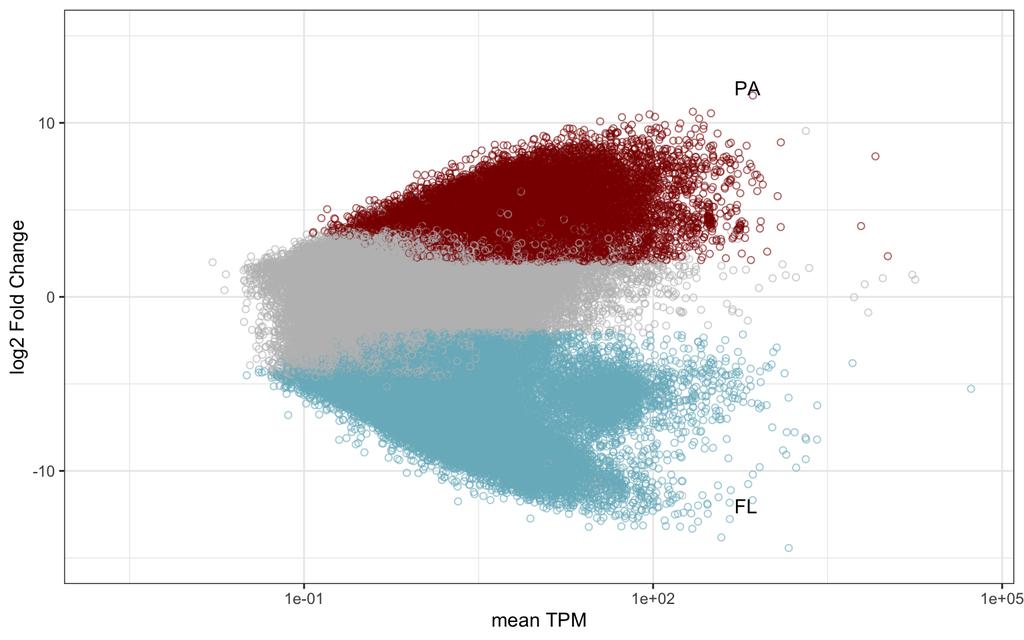

```r
#recreate MA plots with our colors:
#add column to Deseq2 results that if padj<0.001 and FC>2 =upPA, otherwise NA
#add column to deseq2 results that if padj<0.001 and FC<-2=upFL
#summarize these columns into one and create graph meanTPM/log2FC, color according to significance in PA/FL sign.

col.treatment2= c(
                  "sign_NA_NA"="grey",
                  "NA_NA_FL"= "grey",
                  "NA_PA_NA"="grey",
                  "NA_NA_NA"= "grey",
                  "sign_PA_NA" ="red4",  ##f37735
                  "sign_NA_FL"= "#78B7C5")

B<- res_PA_FL %>%
  as.data.frame() %>%
  rownames_to_column( var = "GeneID") %>%
  mutate(sign=ifelse(padj<0.001, yes="sign", NA))%>%
  mutate(upPA=ifelse(log2FoldChange> 2, yes = "PA", NA)) %>%
  mutate(upFL=ifelse(log2FoldChange< -2, yes="FL", NA)) %>%
  unite("Significance",8:10, sep="_", na.rm=FALSE, remove=TRUE) %>%
  right_join(counts_long, by="GeneID")%>%
  group_by(GeneID) %>%
  mutate(meanTPM=mean(TPM)) %>% ungroup() %>%
  select(GeneID, Significance, meanTPM, log2FoldChange) %>%
  unique()

B %>%
  ggplot(aes(x=meanTPM, y=log2FoldChange, col=Significance))+
  geom_point(shape=21, alpha=0.6)+
  scale_color_manual(values=col.treatment2)+
  scale_x_log10() +
  theme_bw()+
  ylim(-15,15)+
  xlab("mean TPM")+ ylab("log2 Fold Change")+
  theme(legend.position = "none") +
  annotate(geom = "text", x = 500, y = -12, label = "FL",
           hjust = "left")+
  annotate(geom = "text", x = 500, y = 12, label = "PA",
           hjust = "left")
```

### 2.1.2 DESeq2 particles PecP vs AlgP

We wanted to compare PecP and AlgP to test if we have different gene functions on the different polysaccharide particles.

matrixes:

```r
#design matrix
coldata= metadata%>%
  mutate(TypeExperiment = paste0(Type,"_",Experiment))%>%
  select(sample, TypeExperiment, Experiment)%>%
  column_to_rownames(var = "sample")
#count matrix
cts <- counts

#test that cols of count matrix and rows of coldata are in same order!
rownames(coldata)<- sub("fb", "", rownames(coldata))
all(rownames(coldata)%in%colnames(cts))
```

```
## [1] TRUE
```

```r
#if TRUE okay, if not it needs to be reordered
```

create object and design matrix:

```r
# Create object and design matrix to test filters against particles
DE_obj <- DESeqDataSetFromMatrix(
  countData = cts,
  colData   = coldata,
  design    = ~ TypeExperiment)

#check the DeSeq object
#DE_obj

# Add annotation.
mcols(DE_obj) <- anno_sub

#Prefiltering low counts to minimum 10 counts per gene (recommented by (http://bioconductor.org/packages/devel/bioc/vignettes/DESeq2/inst/doc/DESeq2.html))
keep <- rowSums(counts(DE_obj)) >= 10
DE_obj <- DE_obj[keep,]
```

add annotation, prefilter low counts & compute DE:

```r
#ref level, filter will become "untreated"

# Compute DE.
dds_PA_mALG_mPec <- DESeq(DE_obj,test = "Wald")
res <- results(dds_PA_mALG_mPec)

#rename results
res_PA_mALG_mPec <- results(dds_PA_mALG_mPec,contrast = c("TypeExperiment","Particle_mPec", "Particle_mAlg"))
summary(res_PA_mALG_mPec)
```

```
##
## out of 146563 with nonzero total read count
## adjusted p-value < 0.1
## LFC > 0 (up)       : 6177, 4.2%
## LFC < 0 (down)     : 1817, 1.2%
## outliers [1]       : 15, 0.01%
## low counts [2]     : 34099, 23%
## (mean count < 2)
## [1] see 'cooksCutoff' argument of ?results
## [2] see 'independentFiltering' argument of ?results
```

```r
head(res_PA_mALG_mPec)
```

```
## log2 fold change (MLE): TypeExperiment Particle_mPec vs Particle_mAlg
## Wald test p-value: TypeExperiment Particle_mPec vs Particle_mAlg
## DataFrame with 6 rows and 6 columns
##                       baseMean     log2FoldChange             lfcSE
##                      <numeric>          <numeric>         <numeric>
## PROKKA_00001   13.455542946759   1.26326473351932 0.592401748146518
## PROKKA_00003 0.939233447889538   1.66949275500486   1.6085621018727
## PROKKA_00004 0.714647518120589 0.0410507370033124  2.27628072400063
## PROKKA_00005   1.0151825044033   1.00581534373928  1.54473287885185
## PROKKA_00007  5.43164807078486  0.734898596446103 0.689828275463076
## PROKKA_00009  1.00609653954924  0.977259972337694  2.32807822882613
##                            stat             pvalue              padj
##                       <numeric>          <numeric>         <numeric>
## PROKKA_00001   2.13244599205145 0.0329701998956557 0.285255521125382
## PROKKA_00003   1.03787895603236  0.299326411909418                NA
## PROKKA_00004 0.0180341275882548  0.985611627955136                NA
## PROKKA_00005  0.651125743168531  0.514965319891694                NA
## PROKKA_00007   1.06533556623606   0.28672410349867 0.903601791926168
## PROKKA_00009  0.419771105728888  0.674652674799288                NA
```

filter results for padj<0.001

```r
#res_PA_FL <- results(dds_PA_mALG_mPec, name="TypeExperiment_Particle_mPec_vs_Particle_mAlg")
#res_PA_FL <- results(dds_PA_mALG_mPec, contrast=c("TypeExperiment","Filter_mPec", "Filter_mAlg"))


#Following the results for padj<0.001 of the comparison PecP and AlgP:

#By default the argument alpha is set to 0.1. If the adjusted p value cutoff will be a value other than 0.1, alpha should be set to that value:

res_PA_mALG_mPec001 <- results(dds_PA_mALG_mPec, contrast = c("TypeExperiment","Particle_mPec", "Particle_mAlg"),alpha=0.001)
summary(res_PA_mALG_mPec001)
```

```
##
## out of 146563 with nonzero total read count
## adjusted p-value < 0.001
## LFC > 0 (up)       : 2660, 1.8%
## LFC < 0 (down)     : 327, 0.22%
## outliers [1]       : 15, 0.01%
## low counts [2]     : 53989, 37%
## (mean count < 3)
## [1] see 'cooksCutoff' argument of ?results
## [2] see 'independentFiltering' argument of ?results
```

```r
resNorm_AlgP_PecP <- lfcShrink(dds_PA_mALG_mPec, contrast = c("TypeExperiment","Particle_mPec", "Particle_mAlg"),type="normal", alpha=0.001, lfcThreshold = 2)
summary(resNorm_AlgP_PecP)
```

```
##
## out of 146563 with nonzero total read count
## adjusted p-value < 0.1
## LFC > 2.00 (up)    : 1746, 1.2%
## LFC < -2.00 (down) : 31, 0.021%
## outliers [1]       : 15, 0.01%
## low counts [2]     : 59672, 41%
## (mean count < 2)
## [1] see 'cooksCutoff' argument of ?results
## [2] see 'independentFiltering' argument of ?results
```

only include data with log2FoldChange <-2 or >2:

```r
#And if we (by hand) only include data with log2FoldChange <-2 or >2, we exclude further GeneIDs.

#export results with FC >2 and <-2, and p-adj <0.001
res_PecP_AlgP_Sign <- res_PA_mALG_mPec001%>%
  as.data.frame()%>%
  rownames_to_column( var = "GeneID")%>%
  subset( padj < 0.001)%>%
  dplyr::filter(!between(log2FoldChange, -2,2))

summary(res_PecP_AlgP_Sign)
```

```
##     GeneID             baseMean         log2FoldChange       lfcSE
##  Length:2782        Min.   :    3.185   Min.   :-7.489   Min.   :0.3147
##  Class :character   1st Qu.:    8.879   1st Qu.: 4.443   1st Qu.:0.6640
##  Mode  :character   Median :   15.939   Median : 5.692   Median :0.9299
##                     Mean   :   63.983   Mean   : 4.824   Mean   :0.9275
##                     3rd Qu.:   36.044   3rd Qu.: 6.531   3rd Qu.:1.1728
##                     Max.   :22543.637   Max.   : 9.741   Max.   :1.6591
##       stat             pvalue               padj
##  Min.   :-13.095   Min.   :0.000e+00   Min.   :0.000e+00
##  1st Qu.:  4.568   1st Qu.:0.000e+00   1st Qu.:6.000e-10
##  Median :  5.422   Median :2.962e-08   Median :1.957e-06
##  Mean   :  5.078   Mean   :3.221e-06   Mean   :1.119e-04
##  3rd Qu.:  6.851   3rd Qu.:1.978e-06   3rd Qu.:8.540e-05
##  Max.   : 15.304   Max.   :3.224e-05   Max.   :9.989e-04
```

MAplot of AlgP vs PecP

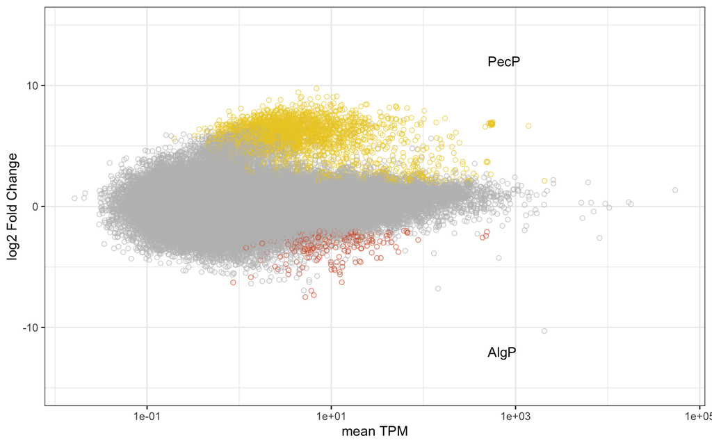

```r
#recreate MA plots with our colors for second comparison:
#add column to Deseq2 results that if padj<0.001 and FC>2 =upPecP, otherwise NA
#add column to deseq2 results that if padj<0.001 and FC<-2=upAlgP
#summarize these columns into one and create graph meanTPM/log2FC, color according to significance in PecP/AlgP sign.
C<- res_PA_mALG_mPec %>%
  as.data.frame() %>%
  rownames_to_column( var = "GeneID") %>%
  mutate(sign=ifelse(padj<0.001, yes="sign", NA))%>%
  mutate(upPA=ifelse(log2FoldChange> 2, yes = "PecP", NA)) %>%
  mutate(upFL=ifelse(log2FoldChange< -2, yes="AlgP", NA)) %>%
  unite("Significance",8:10, sep="_", na.rm=FALSE, remove=TRUE) %>%
  left_join(counts_long, by="GeneID")%>%
  group_by(GeneID) %>%
  mutate(meanTPM=mean(TPM)) %>% ungroup() %>%
  select(GeneID, Significance, meanTPM, log2FoldChange) %>%
  unique()

ggplot(C, aes(x=meanTPM, y=log2FoldChange, col=Significance))+
  geom_point(shape=21, alpha=0.6)+
  scale_color_manual(values=col.treatment)+
  scale_x_log10() +
  theme_bw()+
  ylim(-15,15)+
  xlab("mean TPM")+ ylab("log2 Fold Change")+
  theme(legend.position = "none") +
  annotate(geom = "text", x = 500, y = -12, label = "AlgP",
           hjust = "left")+
  annotate(geom = "text", x = 500, y = 12, label = "PecP",
           hjust = "left")
```

## 2.2 Overview KEGG Carbohydrates Categories

```r
Carbohydr<- counts_long %>%
  left_join(Kegg, by="GeneID") %>%
  filter(Category2 %in% c("Carbohydrate metabolism", "Amino acid metabolism")) %>%
  group_by(sample, Category3) %>%
  mutate(sumTPM=sum(TPM)) %>% ungroup() %>%
  left_join(metadata, by="sample") %>%
  group_by(ManuscriptID, Category3) %>% mutate(meanTPM=mean(sumTPM)) %>% ungroup() %>%
  select(Category2, Category3, meanTPM,ManuscriptID) %>% unique() %>%
  spread(ManuscriptID, meanTPM) %>%
  select(Category2, Category3, FL, AlgP, PecP) %>%
  rename("KEGG_Category2"= "Category2") %>%
  rename("KEGG_Category3"= "Category3") %>%
  arrange(desc(KEGG_Category2))

#write_csv(Carbohydr, "BAH_Suppl_TableXX_Keggcategories.csv")
#Carbohydr
xlsx::write.xlsx(Carbohydr, "BAH_Suppl_TableXX_Keggcategories.xlsx", sheetName = "Sheet1",
  col.names = TRUE)

Carbohydr
```

```
## # A tibble: 29 x 5
##    KEGG_Category2      KEGG_Category3                           FL   AlgP   PecP
##    <chr>               <chr>                                 <dbl>  <dbl>  <dbl>
##  1 Carbohydrate metab… 00010 Glycolysis / Gluconeogenesis … 10341.  9495.  9679.
##  2 Carbohydrate metab… 00020 Citrate cycle (TCA cycle) [PA…  9469. 11416. 11107.
##  3 Carbohydrate metab… 00030 Pentose phosphate pathway [PA…  4045.  6671.  6369.
##  4 Carbohydrate metab… 00040 Pentose and glucuronate inter…  1133.   904.  1161.
##  5 Carbohydrate metab… 00051 Fructose and mannose metaboli…  2404.  3614.  3130.
##  6 Carbohydrate metab… 00052 Galactose metabolism [PATH:ko…  1038.   792.  1330.
##  7 Carbohydrate metab… 00053 Ascorbate and aldarate metabo…   515.   248.   205.
##  8 Carbohydrate metab… 00500 Starch and sucrose metabolism…  2150.  1347.  1544.
##  9 Carbohydrate metab… 00520 Amino sugar and nucleotide su…  4359.  3158.  3085.
## 10 Carbohydrate metab… 00562 Inositol phosphate metabolism…   645.  2014.  1964.
## # … with 19 more rows
```

## 2.3 Major transcripts in the carbohydrate metabolism category

in FL:

```r
counts_long %>%
  left_join(Kegg, by="GeneID") %>%
 # filter(Category3=="00630 Glyoxylate and dicarboxylate metabolism [PATH:ko00630]") %>%
  filter(Category2=="Carbohydrate metabolism") %>%
   group_by(sample, description, Category3) %>%
  mutate(geneTPM= sum(TPM)) %>%  ungroup() %>%
  select(sample, description, geneTPM, Category3) %>% unique() %>%
  left_join(metadata, by="sample") %>%
  group_by(ManuscriptID, description, Category3) %>%
  mutate(meanTPM=mean(geneTPM)) %>% ungroup() %>%
  select(ManuscriptID, Category3, description, meanTPM) %>% unique() %>%
  filter(ManuscriptID=="FL") %>%
  arrange(desc(meanTPM))
```

```
## # A tibble: 531 x 4
##    ManuscriptID Category3                 description                    meanTPM
##    <chr>        <chr>                     <chr>                            <dbl>
##  1 FL           00620 Pyruvate metabolis… aceB, glcB; malate synthase […   5966.
##  2 FL           00630 Glyoxylate and dic… aceB, glcB; malate synthase […   5966.
##  3 FL           00630 Glyoxylate and dic… E4.1.3.1, aceA; isocitrate ly…   4382.
##  4 FL           00010 Glycolysis / Gluco… aldB; aldehyde dehydrogenase …   4076.
##  5 FL           00620 Pyruvate metabolis… aldB; aldehyde dehydrogenase …   4076.
##  6 FL           00650 Butanoate metaboli… phbB; acetoacetyl-CoA reducta…   1164.
##  7 FL           00630 Glyoxylate and dic… phbB; acetoacetyl-CoA reducta…   1164.
##  8 FL           00010 Glycolysis / Gluco… GAPDH, gapA; glyceraldehyde 3…   1019.
##  9 FL           00650 Butanoate metaboli… phaZ; poly(3-hydroxybutyrate)…    955.
## 10 FL           00020 Citrate cycle (TCA… acnB; aconitate hydratase 2 /…    813.
## # … with 521 more rows
```

in PecP:

```r
counts_long %>%
  left_join(Kegg, by="GeneID") %>%
  #filter(Category3=="00630 Glyoxylate and dicarboxylate metabolism [PATH:ko00630]") %>%
 filter(Category2=="Carbohydrate metabolism") %>%
   group_by(sample, description, Category3) %>%
  mutate(geneTPM= sum(TPM)) %>%  ungroup() %>%
  select(sample, description, geneTPM, Category3) %>% unique() %>%
  left_join(metadata, by="sample") %>%
  group_by(ManuscriptID, description, Category3) %>%
  mutate(meanTPM=mean(geneTPM)) %>% ungroup() %>%
  select(ManuscriptID, Category3, description, meanTPM) %>% unique() %>%
  filter(ManuscriptID=="PecP") %>%
  arrange(desc(meanTPM))
```

```
## # A tibble: 531 x 4
##    ManuscriptID Category3                  description                   meanTPM
##    <chr>        <chr>                      <chr>                           <dbl>
##  1 PecP         00630 Glyoxylate and dica… glnA, GLUL; glutamine synthe…   1805.
##  2 PecP         00010 Glycolysis / Glucon… GAPDH, gapA; glyceraldehyde …   1718.
##  3 PecP         00630 Glyoxylate and dica… glyA, SHMT; glycine hydroxym…   1288.
##  4 PecP         00030 Pentose phosphate p… PRPS, prsA; ribose-phosphate…   1266.
##  5 PecP         00020 Citrate cycle (TCA … CS, gltA; citrate synthase […   1234.
##  6 PecP         00630 Glyoxylate and dica… CS, gltA; citrate synthase […   1234.
##  7 PecP         00562 Inositol phosphate … TPI, tpiA; triosephosphate i…   1113.
##  8 PecP         00010 Glycolysis / Glucon… TPI, tpiA; triosephosphate i…   1113.
##  9 PecP         00051 Fructose and mannos… TPI, tpiA; triosephosphate i…   1113.
## 10 PecP         00660 C5-Branched dibasic… sucD; succinyl-CoA synthetas…   1070.
## # … with 521 more rows
```

in AlgP:

```r
counts_long %>%
  left_join(Kegg, by="GeneID") %>%
#  filter(Category3=="00630 Glyoxylate and dicarboxylate metabolism [PATH:ko00630]") %>%
  filter(Category2=="Carbohydrate metabolism") %>%
   group_by(sample, description, Category3) %>%
  mutate(geneTPM= sum(TPM)) %>%  ungroup() %>%
  select(sample, description, geneTPM, Category3) %>% unique() %>%
  left_join(metadata, by="sample") %>%
  group_by(ManuscriptID, description, Category3) %>%
  mutate(meanTPM=mean(geneTPM)) %>% ungroup() %>%
  select(ManuscriptID, Category3, description, meanTPM) %>% unique() %>%
  filter(ManuscriptID=="AlgP") %>%
  arrange(desc(meanTPM))
```

```
## # A tibble: 531 x 4
##    ManuscriptID Category3                  description                   meanTPM
##    <chr>        <chr>                      <chr>                           <dbl>
##  1 AlgP         00630 Glyoxylate and dica… glnA, GLUL; glutamine synthe…   2242.
##  2 AlgP         00010 Glycolysis / Glucon… GAPDH, gapA; glyceraldehyde …   1524.
##  3 AlgP         00630 Glyoxylate and dica… glyA, SHMT; glycine hydroxym…   1262.
##  4 AlgP         00660 C5-Branched dibasic… sucD; succinyl-CoA synthetas…   1228.
##  5 AlgP         00020 Citrate cycle (TCA … sucD; succinyl-CoA synthetas…   1228.
##  6 AlgP         00640 Propanoate metaboli… sucD; succinyl-CoA synthetas…   1228.
##  7 AlgP         00030 Pentose phosphate p… PRPS, prsA; ribose-phosphate…   1215.
##  8 AlgP         00562 Inositol phosphate … TPI, tpiA; triosephosphate i…   1165.
##  9 AlgP         00010 Glycolysis / Glucon… TPI, tpiA; triosephosphate i…   1165.
## 10 AlgP         00051 Fructose and mannos… TPI, tpiA; triosephosphate i…   1165.
## # … with 521 more rows
```

## 2.4 Heatmaps (Fig. 3A)

### 2.4.1 PLs

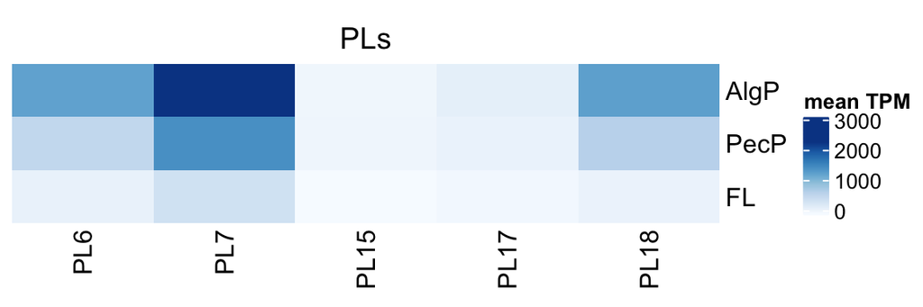

```r
###############
###heatmap of most abundant PLs and mean per treatment

Plswide_sub2<- counts_long %>%
  left_join(dbcan, by="GeneID") %>%
  left_join(metadata, by="sample") %>%
  select(HMM_Profile_simple, sample,ManusRep, ManuscriptID, TPM)%>% unique() %>%
  group_by(HMM_Profile_simple, ManusRep)%>%
  mutate(PL_main_summed_TPM=sum(TPM))%>% ungroup()%>%
  group_by(ManuscriptID, HMM_Profile_simple) %>%
  mutate(PL_main_mean_TPM= mean(PL_main_summed_TPM))%>%  ungroup()%>%
  filter(ManuscriptID!="PecP") %>%

 # filter(PL_main_mean_TPM>50)
 # filter(grepl("PL", HMM_Profile_simple))%>%
  filter(HMM_Profile_simple %in% c("PL6", "PL7", "PL15", "PL17","PL18" ))%>%
  select(HMM_Profile_simple,  ManuscriptID, PL_main_mean_TPM)%>% unique()%>%
  spread(ManuscriptID, PL_main_mean_TPM)

Plsanno_sub2<- Plswide_sub2%>%
  select(HMM_Profile_simple) %>% unique()

mat3_sub2 = as.matrix(Plswide_sub2)
rownames(mat3_sub2) <- Plswide_sub2$HMM_Profile_simple
mat3_sub2<- Plswide_sub2 %>% as.data.frame()%>%select(-HMM_Profile_simple) %>% as.matrix()


test<-   counts_long %>% left_join(dbcan, by="GeneID") %>%
  left_join(metadata, by="sample") %>%
  select(HMM_Profile_simple, sample,ManusRep, ManuscriptID, TPM)%>% unique() %>%
  group_by(HMM_Profile_simple, ManusRep)%>%
  mutate(PL_main_summed_TPM=sum(TPM))%>% ungroup()%>%
  group_by(ManuscriptID, HMM_Profile_simple) %>%
  mutate(PL_main_mean_TPM= mean(PL_main_summed_TPM))%>%  ungroup()%>%
  #filter(grepl("PL", HMM_Profile_simple))%>%
  #  filter(ManuscriptID!="PecP") %>%
  filter(HMM_Profile_simple %in% c("PL6", "PL7", "PL15", "PL17","PL18" ))%>%
  select(HMM_Profile_simple,  ManuscriptID, PL_main_mean_TPM)%>% unique()%>%
  spread(HMM_Profile_simple, PL_main_mean_TPM) %>% arrange(c("AlgP","PecP", "FL")) #ManuscriptID


testM<- test %>%
  select("PL6", "PL7", "PL15", "PL17","PL18" ) %>% as.matrix()  #AlgP, PecP, FL
rownames(testM) <- test[,1] %>% as.matrix()

Heatmap(testM, name = "mean TPM", column_title = "PLs", cluster_rows = FALSE, cluster_columns  = FALSE,
        col= colorRampPalette(brewer.pal(8, "Blues"))(2500))
```

### 2.4.2 CBMs

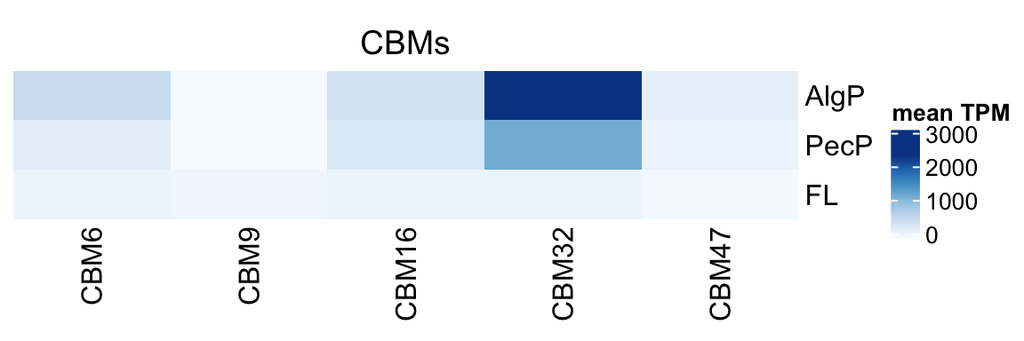

```r
CBMswide_sub3<- counts_long %>%
  left_join(dbcan, by="GeneID") %>%
  left_join(metadata, by="sample") %>%
  select(HMM_Profile_simple, sample, ManusRep,ManuscriptID, TPM)%>% unique() %>%
  group_by(HMM_Profile_simple, ManusRep)%>%
  mutate(PL_main_summed_TPM=sum(TPM))%>% ungroup()%>%
  group_by(ManuscriptID, HMM_Profile_simple)%>%
  mutate(PL_main_mean_TPM= mean(PL_main_summed_TPM))%>%
  ungroup()%>%
 # filter(grepl("CBM", HMM_Profile_simple)) %>%
 # filter(PL_main_mean_TPM>50) %>%
#  filter(ManuscriptID!="PecP") %>%
  filter(HMM_Profile_simple %in% c("CBM6", "CBM9", "CBM16", "CBM32", "CBM47"))%>%
  select(HMM_Profile_simple,  ManuscriptID, PL_main_mean_TPM)%>% unique()%>%
  #spread(ManuscriptID, PL_main_mean_TPM)
   spread(HMM_Profile_simple, PL_main_mean_TPM)%>% arrange(c("AlgP", "PecP", "FL"))

CBMsanno_sub3<- CBMswide_sub3%>%
  select(ManuscriptID) %>% unique()

mat4_sub3 = as.matrix(CBMswide_sub3)
rownames(mat4_sub3) <- CBMswide_sub3$ManuscriptID
mat4_sub3<- CBMswide_sub3 %>% as.data.frame()%>%select(-ManuscriptID) %>% as.matrix()


CBMswide_sub3M<- CBMswide_sub3 %>%
  select("CBM6", "CBM9", "CBM16", "CBM32", "CBM47") %>% as.matrix()
rownames(CBMswide_sub3M) <- CBMswide_sub3[,1] %>% as.matrix()


#CBMheat<-heatmap(CBMswide_sub3M, scale="column",
#        cexRow=1.5,
 #       labRow=paste("", rownames(CBMswide_sub3M),sep=""),
  #      col= colorRampPalette(brewer.pal(8, "Blues"))(2500),
   #     Colv=NA)


Heatmap(CBMswide_sub3M, name = "mean TPM", column_title = "CBMs", cluster_rows = FALSE, cluster_columns  = FALSE,
        col= colorRampPalette(brewer.pal(8, "Blues"))(2500))
```

### 2.4.3 GHs

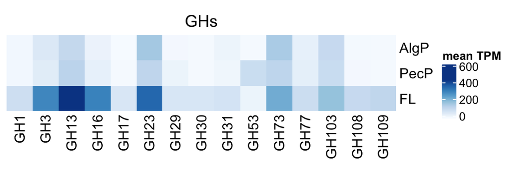

```r
### heatmap of most abundant GHs and mean per treatment

GHswide_sub3<- counts_long %>%
  left_join(dbcan, by="GeneID") %>%
  left_join(metadata, by="sample") %>%
  select(HMM_Profile_simple, sample, ManusRep, ManuscriptID, TPM)%>% unique() %>%
  group_by(HMM_Profile_simple, ManusRep)%>%
  mutate(PL_main_summed_TPM=sum(TPM))%>% ungroup()%>%
  group_by(HMM_Profile_simple, ManuscriptID)%>%
  mutate(PL_main_mean_TPM= mean(PL_main_summed_TPM))%>%  ungroup()%>%
 # filter(ManuscriptID!="PecP") %>%
 # filter(grepl("GH", HMM_Profile_simple)) %>%
  #filter(PL_main_mean_TPM>50) %>%
  filter(HMM_Profile_simple %in% c("GH1",  "GH3",  "GH13",  "GH16", "GH17",
                             "GH23", "GH29", "GH30",  "GH31", "GH53",
                             "GH73", "GH77", "GH103", "GH108","GH109" ))%>%
  select(HMM_Profile_simple,  ManuscriptID, PL_main_mean_TPM)%>% unique()%>%
  #spread(ManuscriptID, PL_main_mean_TPM)
  spread(HMM_Profile_simple, PL_main_mean_TPM)%>% arrange(c("AlgP",  "PecP", "FL"))

GHsanno_sub2<- GHswide_sub3%>%
  select(ManuscriptID) %>% unique()

mat3_sub2 = as.matrix(GHswide_sub3)
rownames(mat3_sub2) <- GHswide_sub3$ManuscriptID
mat3_sub2<- GHswide_sub3 %>% as.data.frame()%>%select(-ManuscriptID) %>% as.matrix()

GHswide_sub3M<- GHswide_sub3 %>%
  select("GH1",  "GH3",  "GH13",  "GH16", "GH17",
                             "GH23", "GH29", "GH30",  "GH31", "GH53",
                             "GH73", "GH77", "GH103", "GH108","GH109" ) %>% as.matrix()
rownames(GHswide_sub3M) <- GHswide_sub3[,1] %>% as.matrix()


#GHheat<-heatmap(GHswide_sub3M, scale="column",
#        cexRow=1.5,
#        labRow=paste("", rownames(GHswide_sub3M),sep=""),
#        col= colorRampPalette(brewer.pal(8, "Blues"))(2500),
#        Colv=NA)

Heatmap(GHswide_sub3M, name = "mean TPM", column_title = "GHs", cluster_rows = FALSE, cluster_columns  = FALSE,
        col= colorRampPalette(brewer.pal(8, "Blues"))(2500))
```

## 2.5 MAGs MT abundance

## 2.6 selected MAGs functional MT

- used datafile for MAG CAZyme diversity: MAGs_dbcan_heatmap.txt

```r
#for this figure, I first filter out all Genes belonging to the depicted Bins
#I then summed all TPMs per HMM-profile per sample and take then per treatment and PL-main, I calculated the mean that will be plotted in the graph.
annobins<- annotation %>%
  select(GeneID, auto_bin) %>% unique()


ggbins3<-  counts_long %>%
  select(GeneID, sample, TPM) %>%
  left_join(annobins, by="GeneID") %>%
  left_join(dbcan, by="GeneID") %>%
  filter(auto_bin %in% c( "24","57","32" , "73", "26")) %>%
  select(GeneID, auto_bin, HMM_Profile_simple, sample, TPM) %>%
  left_join(metadata, by="sample") %>%
  filter(HMM_Profile_simple!="NA") %>%
  na.omit() %>%
 select(-GeneID) %>%
  group_by(HMM_Profile_simple, sample, auto_bin) %>%
    mutate(HMM_TPM=sum(TPM)) %>%
    ungroup() %>% unique() %>%
  group_by(HMM_Profile_simple, ManuscriptID, auto_bin) %>%
   mutate(meanTPM=mean(HMM_TPM)) %>%
   ungroup() %>%
  filter(ManuscriptID!="PecP") %>%
  filter(HMM_Profile_simple!="NA") %>%
  select(auto_bin, HMM_Profile_simple,  ManuscriptID,meanTPM) %>% unique() %>%
  dplyr::filter(!grepl('AAS|GT|AA|CE', HMM_Profile_simple)) %>%
  mutate(auto_bin=as.character(auto_bin))


ggbins3$ManuscriptID<- factor(ggbins3$ManuscriptID,levels = c("AlgP", "FL"))
```

```r
xxx<- ggbins3 %>%
  ggplot(aes(x=HMM_Profile_simple, y=ManuscriptID, fill=meanTPM))+ #log10(meanTPM)))+
  geom_tile()+
  viridis::scale_fill_viridis(discrete=FALSE)+
  facet_wrap(~auto_bin,  ncol=1)+
  theme_bw()+
  theme(axis.text.x = element_text(angle = 90)) +
  ggtitle("transcript abundances of CAZymes and PULs in MAGs")


#### and in the MG MAGs
MGmags<- read_tsv("data_used/MAGs_dbcan_heatmap.txt") %>%
  gather(HMM_Profile_simple, copies, 2:39) %>%
  separate(MAG , c("bin","Taxa"), "_", remove=F)  %>%
  separate(bin, c("xx", "auto_bin"), "bin", remove=T) %>%
  left_join(ggbins3, by=c("auto_bin", "HMM_Profile_simple"))

MGmags$ManuscriptID<- factor(MGmags$ManuscriptID,levels = c("AlgP",  "FL"))
```

## 2.7 MG/MT Mags PULS and CAZymes (Fig. 5)

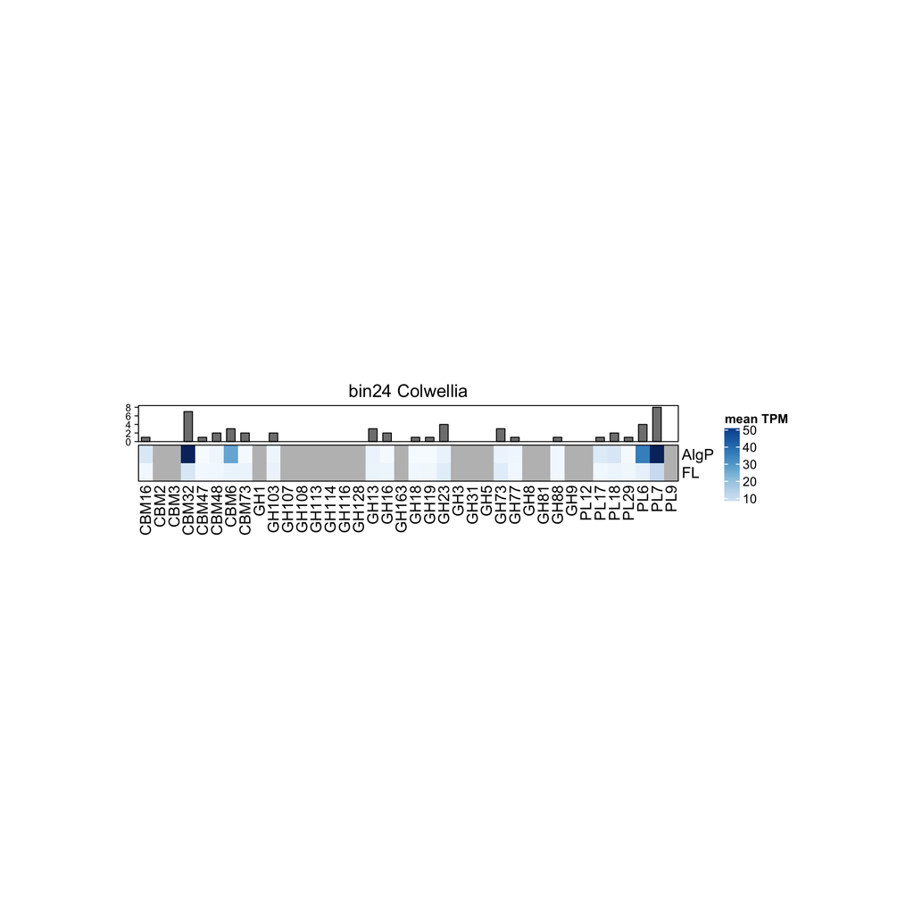

```r
#for this figure, I first filter out all Genes belonging to the depicted Bins
#I then summed all TPMs per HMM-profile per sample and take then per treatment and PL-main, I calculated the mean that will be plotted in the graph


#bin 24:

MTmags24<- ggbins3 %>%
    dplyr::filter(!grepl('AAS|GT|AA|CE', HMM_Profile_simple)) %>%
  spread(HMM_Profile_simple, meanTPM) %>%
  filter(auto_bin=="24") %>% select(-auto_bin)  %>%
  arrange(c("AlgP", "FL"))


MTmags24<- MTmags24 %>% select(-"ManuscriptID")%>%  as.matrix()

mgmags24<- read_tsv("data_used/MAGs_dbcan_heatmap.txt") %>%
  filter(MAG=="bin24_Colwellia") %>%
  select(-MAG) %>%
  t()
rownames(mgmags24) <- mgmags24[,1] %>% as.matrix()



column_ha24 = HeatmapAnnotation(" " = anno_barplot(mgmags24[,1]))
rownames(MTmags24) <- c("AlgP", "FL")

Heatmap(MTmags24,
        name = "mean TPM",
        cluster_columns = FALSE,
        cluster_rows=FALSE,
        row_title = character(0),
        column_title ="bin24 Colwellia",

        col= colorRampPalette(brewer.pal(9, "Blues"))(200),
        top_annotation = column_ha24,
        width=unit(15, "cm"), height=unit(1, "cm"),
        border = TRUE)
```

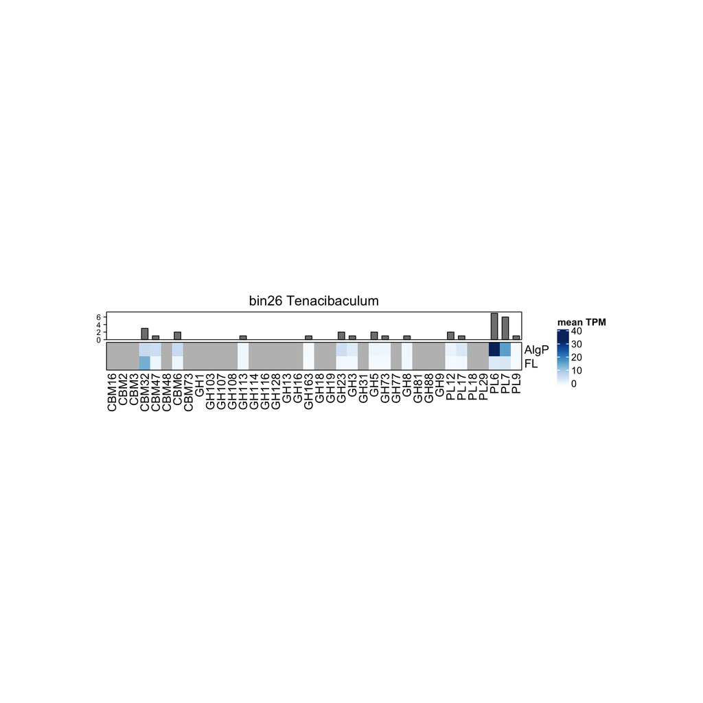

```r
###########
#bin 26:

MTmags26<- ggbins3 %>%
 dplyr::filter(!grepl('AAS|GT|AA|CE', HMM_Profile_simple)) %>%
  spread(HMM_Profile_simple, meanTPM) %>%
  filter(auto_bin=="26") %>% select(-auto_bin)  %>%
  arrange(c("AlgP", "FL"))

MTmags26<- MTmags26 %>% select(-"ManuscriptID")%>%  as.matrix()

mgmags26<- read_tsv("data_used/MAGs_dbcan_heatmap.txt") %>%

  filter(MAG=="bin26_Tenacibaculum") %>%  select(-MAG) %>% t()

column_ha26 = HeatmapAnnotation(" " = anno_barplot(mgmags26[,1]))
rownames(MTmags26) <- c("AlgP", "FL")

Heatmap(MTmags26,
        name = "mean TPM",
        cluster_columns = FALSE,
        cluster_rows=FALSE,
        row_title = character(0),
        column_title ="bin26 Tenacibaculum",

        col= colorRampPalette(brewer.pal(9, "Blues"))(200),
        top_annotation = column_ha26,
        width=unit(15, "cm"), height=unit(1, "cm"),
        border = TRUE)
```

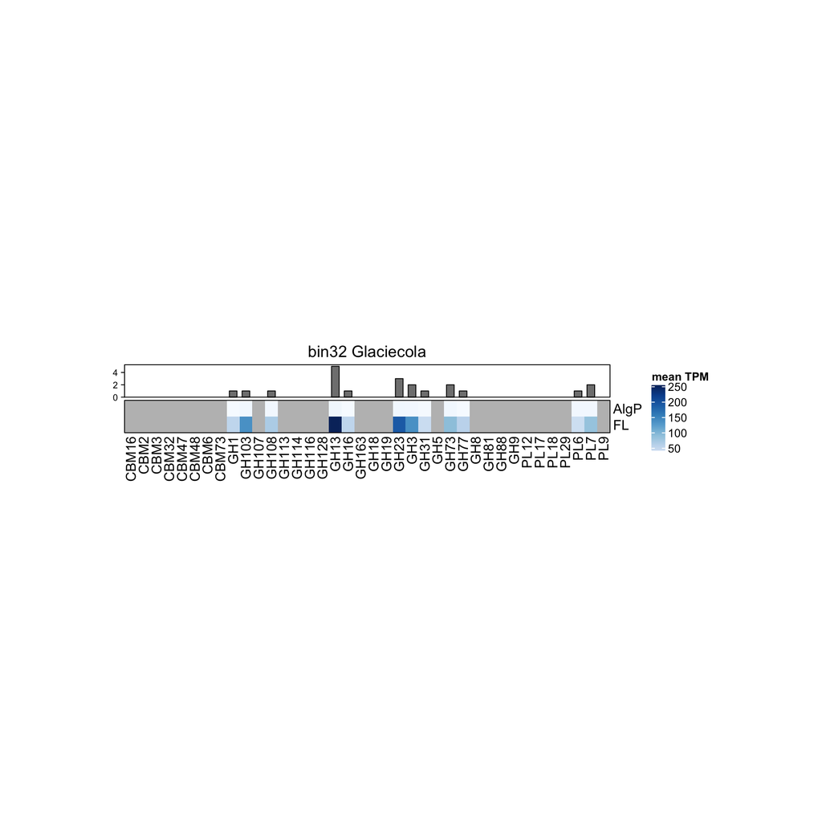

```r
#bin 32:

MTmags32<- ggbins3 %>%
  dplyr::filter(!grepl('AAS|GT|AA|CE', HMM_Profile_simple)) %>%
  spread(HMM_Profile_simple, meanTPM) %>%
  filter(auto_bin=="32") %>% select(-auto_bin)  %>%
  arrange(c("AlgP", "FL")) #, "FL"

MTmags32<- MTmags32 %>% select(-"ManuscriptID")%>%  as.matrix()

mgmags32<- read_tsv("data_used/MAGs_dbcan_heatmap.txt") %>%

  filter(MAG=="bin32_Glaciecola") %>%  select(-MAG) %>% t()



column_ha32 = HeatmapAnnotation(" " = anno_barplot(mgmags32[,1]))
rownames(MTmags32) <- c("AlgP", "FL")

Heatmap(MTmags32,
        name = "mean TPM",
        cluster_columns = FALSE,
        cluster_rows=FALSE,
        row_title = character(0),
        column_title ="bin32 Glaciecola",

        col= colorRampPalette(brewer.pal(9, "Blues"))(200),
        top_annotation = column_ha32,
        width=unit(15, "cm"), height=unit(1, "cm"),
        border = TRUE)
```

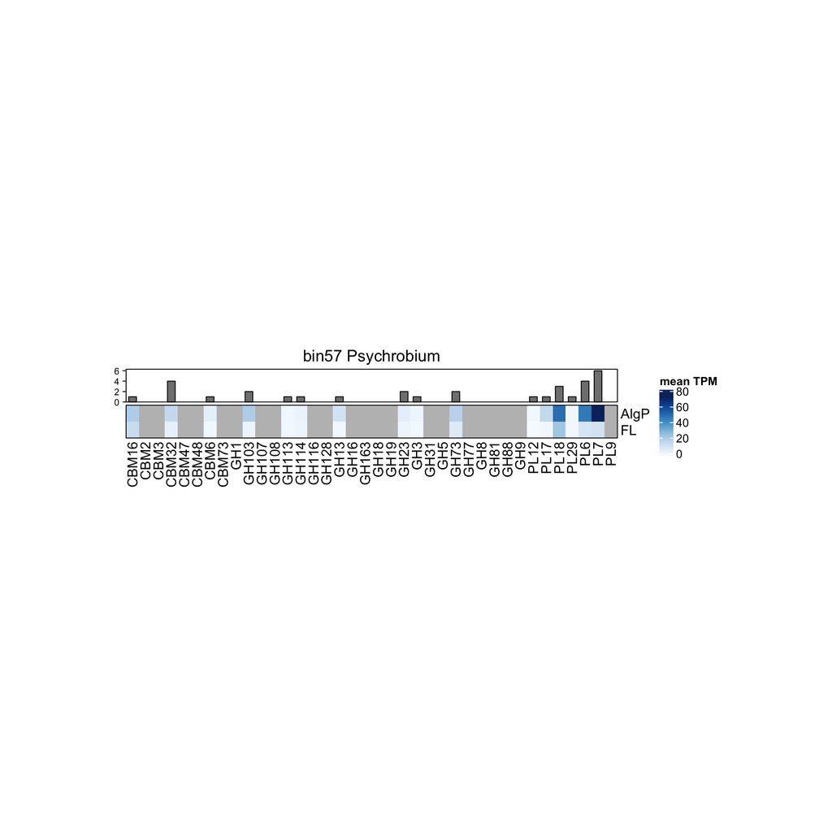

```r
#bin 57:

MTmags57<- ggbins3 %>%
  dplyr::filter(!grepl('AAS|GT|AA|CE', HMM_Profile_simple)) %>%
  spread(HMM_Profile_simple, meanTPM) %>%
  filter(auto_bin=="57") %>% select(-auto_bin)  %>%
  arrange(c("AlgP", "FL")) #, "FL"

MTmags57<- MTmags57 %>% select(-"ManuscriptID")%>%  as.matrix()

mgmags57<- read_tsv("data_used/MAGs_dbcan_heatmap.txt") %>%

  filter(MAG=="bin57_Psychrobium") %>%  select(-MAG) %>% t()



column_ha57 = HeatmapAnnotation(" " = anno_barplot(mgmags57[,1]))
rownames(MTmags57) <- c("AlgP", "FL")

Heatmap(MTmags57,
        name = "mean TPM",
        cluster_columns = FALSE,
        cluster_rows=FALSE,
        row_title = character(0),
        column_title ="bin57 Psychrobium",

        col= colorRampPalette(brewer.pal(9, "Blues"))(200),
        top_annotation = column_ha57,
        width=unit(15, "cm"), height=unit(1, "cm"),
        border = TRUE)
```

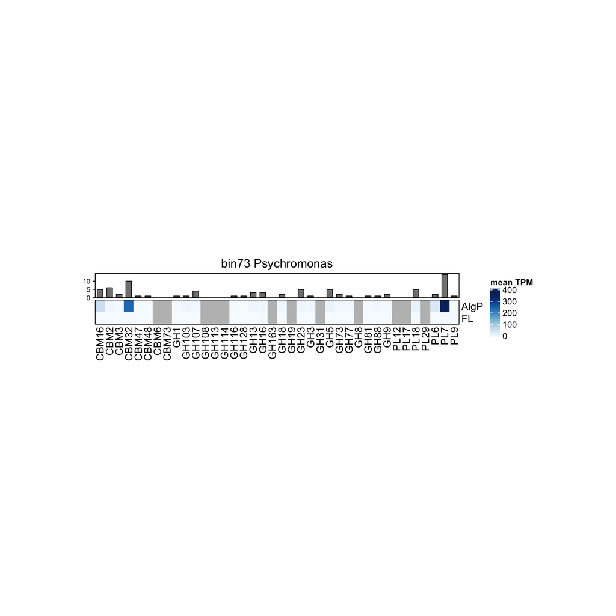

```r
#bin 73:

MTmags73<- ggbins3 %>%
  dplyr::filter(!grepl('AAS|GT|AA|CE', HMM_Profile_simple)) %>%
  spread(HMM_Profile_simple, meanTPM) %>%
  filter(auto_bin=="73") %>% select(-auto_bin)  %>%
  arrange(c("AlgP", "FL")) #, "FL"

MTmags73<- MTmags73 %>% select(-"ManuscriptID")%>%  as.matrix()

mgmags73<- read_tsv("data_used/MAGs_dbcan_heatmap.txt") %>%

  filter(MAG=="bin73_Psychromonas") %>%  select(-MAG) %>% t()


column_ha73 = HeatmapAnnotation(" " = anno_barplot(mgmags73[,1]))
rownames(MTmags73) <- c("AlgP", "FL")

Heatmap(MTmags73,
        name = "mean TPM",
        cluster_columns = FALSE,
        cluster_rows=FALSE,
        row_title = character(0),
        column_title ="bin73 Psychromonas",

        col= colorRampPalette(brewer.pal(9, "Blues"))(200),
        top_annotation = column_ha73,
        width=unit(15, "cm"), height=unit(1, "cm"),
        border = TRUE)
```

## 2.8 PL7 homologues transcript abundances of MAG73 (Fig. S8)

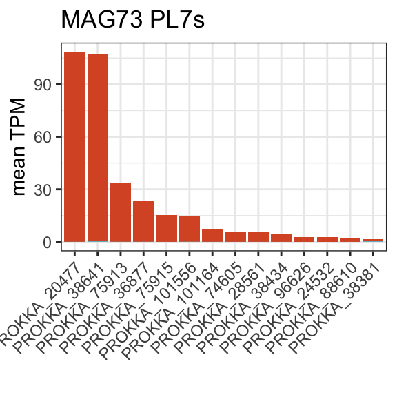

```r
eveness<- counts_long %>%
  left_join(annotation, by="GeneID") %>%
  left_join(metadata, by="sample") %>%
  group_by(HK,ManuscriptID, auto_bin) %>%
  mutate(meanTPM=mean(TPM)) %>%  ungroup() %>%
  select(GeneID, HK, meanTPM, ManuscriptID, auto_bin, HMM_Profile_simple) %>% unique() %>%
  filter(auto_bin %in% c( "24", "26","32" ,"57", "73")) %>%
  filter(HMM_Profile_simple %in% c( "PL6", "PL7")) %>%
  filter(ManuscriptID!="PecP")

eveness %>%
  filter(auto_bin=="73") %>%
  filter(HMM_Profile_simple=="PL7") %>%
  ggplot(aes(x=reorder(GeneID, -meanTPM), y=meanTPM, fill=ManuscriptID))+
  geom_col()+   scale_fill_manual(values=col.treatment)+
  theme_bw()+
   theme(axis.text.x = element_text(angle = 45, vjust = 1, hjust=1))+
  xlab("")+ ylab("mean TPM")+ ggtitle("MAG73 PL7s")+
  theme(legend.position="")
```

## 2.9 most abundant transcripts in the carbohydrate metabolism category

### 2.9.1 FL

```r
counts_long %>%
  left_join(Kegg, by="GeneID") %>%

  filter(Category2=="Carbohydrate metabolism") %>%
   group_by(sample, description, Category3) %>%
  mutate(geneTPM= sum(TPM)) %>%  ungroup() %>%
  select(sample, description, geneTPM, Category3) %>% unique() %>%
  left_join(metadata, by="sample") %>%
  group_by(ManuscriptID, description, Category3) %>%
  mutate(meanTPM=mean(geneTPM)) %>% ungroup() %>%
  select(ManuscriptID, Category3, description, meanTPM) %>% unique() %>%
  filter(ManuscriptID=="FL") %>%
  arrange(desc(meanTPM))
```

```
## # A tibble: 531 x 4
##    ManuscriptID Category3                 description                    meanTPM
##    <chr>        <chr>                     <chr>                            <dbl>
##  1 FL           00620 Pyruvate metabolis… aceB, glcB; malate synthase […   5966.
##  2 FL           00630 Glyoxylate and dic… aceB, glcB; malate synthase […   5966.
##  3 FL           00630 Glyoxylate and dic… E4.1.3.1, aceA; isocitrate ly…   4382.
##  4 FL           00010 Glycolysis / Gluco… aldB; aldehyde dehydrogenase …   4076.
##  5 FL           00620 Pyruvate metabolis… aldB; aldehyde dehydrogenase …   4076.
##  6 FL           00650 Butanoate metaboli… phbB; acetoacetyl-CoA reducta…   1164.
##  7 FL           00630 Glyoxylate and dic… phbB; acetoacetyl-CoA reducta…   1164.
##  8 FL           00010 Glycolysis / Gluco… GAPDH, gapA; glyceraldehyde 3…   1019.
##  9 FL           00650 Butanoate metaboli… phaZ; poly(3-hydroxybutyrate)…    955.
## 10 FL           00020 Citrate cycle (TCA… acnB; aconitate hydratase 2 /…    813.
## # … with 521 more rows
```

### 2.9.2 PecP

```r
counts_long %>%
  left_join(Kegg, by="GeneID") %>%

 filter(Category2=="Carbohydrate metabolism") %>%
   group_by(sample, description, Category3) %>%
  mutate(geneTPM= sum(TPM)) %>%  ungroup() %>%
  select(sample, description, geneTPM, Category3) %>% unique() %>%
  left_join(metadata, by="sample") %>%
  group_by(ManuscriptID, description, Category3) %>%
  mutate(meanTPM=mean(geneTPM)) %>% ungroup() %>%
  select(ManuscriptID, Category3, description, meanTPM) %>% unique() %>%
  filter(ManuscriptID=="PecP") %>%
  arrange(desc(meanTPM))
```

```
## # A tibble: 531 x 4
##    ManuscriptID Category3                  description                   meanTPM
##    <chr>        <chr>                      <chr>                           <dbl>
##  1 PecP         00630 Glyoxylate and dica… glnA, GLUL; glutamine synthe…   1805.
##  2 PecP         00010 Glycolysis / Glucon… GAPDH, gapA; glyceraldehyde …   1718.
##  3 PecP         00630 Glyoxylate and dica… glyA, SHMT; glycine hydroxym…   1288.
##  4 PecP         00030 Pentose phosphate p… PRPS, prsA; ribose-phosphate…   1266.
##  5 PecP         00020 Citrate cycle (TCA … CS, gltA; citrate synthase […   1234.
##  6 PecP         00630 Glyoxylate and dica… CS, gltA; citrate synthase […   1234.
##  7 PecP         00562 Inositol phosphate … TPI, tpiA; triosephosphate i…   1113.
##  8 PecP         00010 Glycolysis / Glucon… TPI, tpiA; triosephosphate i…   1113.
##  9 PecP         00051 Fructose and mannos… TPI, tpiA; triosephosphate i…   1113.
## 10 PecP         00660 C5-Branched dibasic… sucD; succinyl-CoA synthetas…   1070.
## # … with 521 more rows
```

### 2.9.3 AlgP

```r
counts_long %>%
  left_join(Kegg, by="GeneID") %>%

  filter(Category2=="Carbohydrate metabolism") %>%
   group_by(sample, description, Category3) %>%
  mutate(geneTPM= sum(TPM)) %>%  ungroup() %>%
  select(sample, description, geneTPM, Category3) %>% unique() %>%
  left_join(metadata, by="sample") %>%
  group_by(ManuscriptID, description, Category3) %>%
  mutate(meanTPM=mean(geneTPM)) %>% ungroup() %>%
  select(ManuscriptID, Category3, description, meanTPM) %>% unique() %>%
  filter(ManuscriptID=="AlgP") %>%
  arrange(desc(meanTPM))
```

```
## # A tibble: 531 x 4
##    ManuscriptID Category3                  description                   meanTPM
##    <chr>        <chr>                      <chr>                           <dbl>
##  1 AlgP         00630 Glyoxylate and dica… glnA, GLUL; glutamine synthe…   2242.
##  2 AlgP         00010 Glycolysis / Glucon… GAPDH, gapA; glyceraldehyde …   1524.
##  3 AlgP         00630 Glyoxylate and dica… glyA, SHMT; glycine hydroxym…   1262.
##  4 AlgP         00660 C5-Branched dibasic… sucD; succinyl-CoA synthetas…   1228.
##  5 AlgP         00020 Citrate cycle (TCA … sucD; succinyl-CoA synthetas…   1228.
##  6 AlgP         00640 Propanoate metaboli… sucD; succinyl-CoA synthetas…   1228.
##  7 AlgP         00030 Pentose phosphate p… PRPS, prsA; ribose-phosphate…   1215.
##  8 AlgP         00562 Inositol phosphate … TPI, tpiA; triosephosphate i…   1165.
##  9 AlgP         00010 Glycolysis / Glucon… TPI, tpiA; triosephosphate i…   1165.
## 10 AlgP         00051 Fructose and mannos… TPI, tpiA; triosephosphate i…   1165.
## # … with 521 more rows
```